# R이 뭐에요?

R로 배우는 데이터 분석 - 동화고

2022/08/08

# 왜 R을 사용하는가?

1. **R이란?**
2. **R Studio**
3. **R Packages**

## R이란?

> 다재다능한 오픈 소스 프로그래밍이자 스크립트 기반 언어

> 통계와 데이터 분석에 특화된 프로그래밍 언어
- Java Script - building websites
- Python - general

> 다양한 패키지 존재 (약 19000개의 패키지 활용 가능)
- 통계분석
- 머신 러닝
- 데이터 가공
- 그리고.. 강력한 시각화

*예를 들어…*

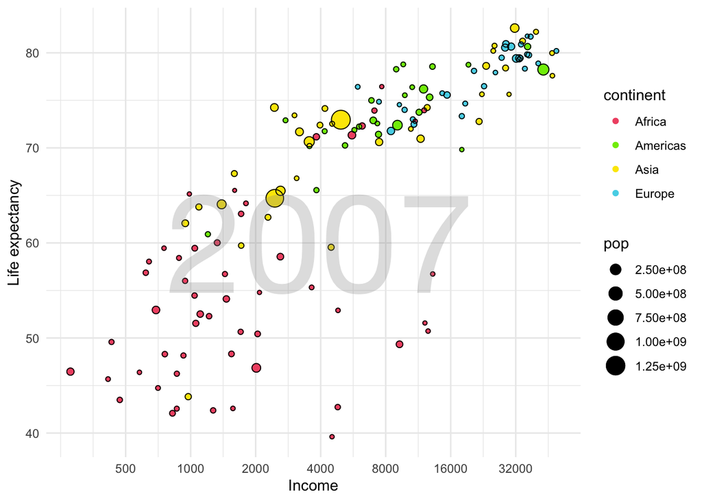

## R Studio

RStudio is an *integrated development environment (IDE)*

> 사용자에게 친숙한 통합형 인터페이스 제공

**Console**

**Script**

**Environment**

### Console

> 콘솔창에 직접 입력 및 산출이 가능하지만 저장기능이 없음

```r
> 2 + 2
```

> `>` 부호의 경우 입력이 완료된 상태로 볼 수 있으나 `+` 부호의 경우 아직 추가 코드를 더 기다리고 있는 상태

```r
> "This is an incomplete quote
+
```

> 코드 실행 결과
1. **Error**: 말 그대로 코드에 에러가 있는 경우이며 결과가 도출되지 않음.
2. **Warning**: 코드 결과가 도출되지만 코더의 의도대로 결과가 도출되지 않을 수도 있음을 항상 명심해야 함.
3. **Messages**: 위 2개의 메세지를 제외하고 나머지 메세지는 양호한 결과이며 크게 걱정하지 않아도 됨.

### Script

> 콘솔창 보다는 스크립트를 활용하여 코드를 작성하는 것이 더 바람직함

> 스크립트 창 여는 법 좌측 상단 메뉴 중 *File* 버튼 클릭 후 *New File* -> *R Script* 클릭 혹은 **`Ctrl + Shift + N`** 동시 클릭하여 스크립트 창 생성

> 스크립트에서 코드 실행 방법 - **`Cmd/Ctrl + Enter`**

### Environment

> R Studio 우측 상단에 있는 칸의 __Global Envrionment__는 현재 코더가 생성하거나 불러온 다양한 형태의 데이터 자료 ( *e.g. dataframe, vector*) 혹은 함수( *function* )를 보여주는 주기능을 수행함.

> R Studio 우측 하단칸은 다양한 역할을 수행하는데 대표적으로 1)현재 작업하고 있는 디렉토리, 2)시각화 결과, 3)첨부한 패키지, 4)코드에 대한 도움 등의 기능들을 수행함.

## R Packages

> R 자체가 오픈 소스 프로그램인 만큼 R의 특장점은 기존에 빌트인 되어있는 기본 패키지 뿐만 아니라 다양한 유저들이 만든 함수(function)들의 집합을 패키지(package)로 다운받아 활용할 수 있음. 구글 앱 스토어에서 앱을 다운받고 실행하듯이 R 또한 패키지를 활용하는 방법또한 install -> attach의 two step process로 굉장히 간단함.

### Install Packages

> 패키지를 다운받기 앞서 초기 설정 상 여러개의 CRAN mirror (서버 아카이브) 중 대한민국에서 제공하는 서버 선택.

> 앞서 시각화에 필요한 ggplot2 package를 예로 들어 구체적인 패키지 다운로드 방법을 설명하자면 설치 코드는 `install.packages("package-name")`로 다음과 같음.

```r
install.packages("ggplot2")
```

*중요한 점은 설치 코드는 매번 R을 킬 때마다 계속 적용할 필요 없이 한 번만 설치하면 된다.*

### Loading Packages

> 패키지 설치를 마쳤으면 R은 패키지를 실행시키는 코드를 따로 입력해야 한다. 해당 코드는 설치 코드와 달리 R을 재실행 시킬 때 마다 실행해줘야 패키지 안에 존재하는 코드를 사용할 수 있음.

```r
library(ggplot2)
```

#### Practice

> 패키지를 설치하는 법을 배웠으니 이제 실제로 수업에서 사용할 패키지들을 다운로드 해보자.
- `dplyr`
- `readxl`
- `stargazer`
- `ggplot2`

### Working Directory

말 그대로 작업공간을 의미하며 외부에서 데이터를 불러오거나 분석한 데이터를 저장할 공간을 설정할 때 필요

> 현재 작업 공간 확인

```r
getwd()
```

> 작업 공간 변경하기

```r
setwd("/Users/jongk/Google 드라이브/R_session/Beginning with the R program")
```

### Load Dataset

작업공간을 설정했으니 실제 액셀에서 작업하던 데이터를 불러와보자.

> 액셀(csv) 파일 불러오기

```r
## read csv file
data1 <- read.csv("your data name.csv")
```

> 다른 확장자명의 파일도 불러올 수 있을까?

```r
## read xlsx file
library(readxl)

data2 <- read_excel("your data name.xlsx")
```